# CS 422 HW8

Ramesh Chandra Reddy Musilanna

## 2. Programming Problem

### 2.1. K-means clustering

```r
library("factoextra")
```

```r
library("ggplot2")
library("dplyr")
library("cluster")
library("fpc")
library("dbscan")
file19.df <- read.csv("file19.csv", header = TRUE, sep = ",")
head(file19.df)
```

|  | X4 | Name | I | i | C | c | P | p | M | m |
| --- | --- | --- | --- | --- | --- | --- | --- | --- | --- | --- |
| 1 | 5 | Opossum | 5 | 4 | 1 | 1 | 3 | 3 | 4 | 4 |
| 2 | 6 | Hairy tail mole | 3 | 3 | 1 | 1 | 4 | 4 | 3 | 3 |
| 3 | 7 | Common mole | 3 | 2 | 1 | 0 | 3 | 3 | 3 | 3 |
| 4 | 8 | Star nose mole | 3 | 3 | 1 | 1 | 4 | 4 | 3 | 3 |
| 5 | 9 | Brown bat | 2 | 3 | 1 | 1 | 3 | 3 | 3 | 3 |
| 6 | 10 | Silver hair bat | 2 | 3 | 1 | 1 | 2 | 3 | 3 | 3 |

### 2.1.a.i

```r
summary(file19.df)
```

```
##        X4            Name                 I               i
##  Min.   : 5.00   Length:66          Min.   :0.000   Min.   :0.000
##  1st Qu.:21.25   Class :character   1st Qu.:1.000   1st Qu.:1.000
##  Median :37.50   Mode  :character   Median :2.000   Median :3.000
##  Mean   :37.50                      Mean   :1.803   Mean   :2.379
##  3rd Qu.:53.75                      3rd Qu.:3.000   3rd Qu.:3.000
##  Max.   :70.00                      Max.   :5.000   Max.   :4.000
##        C                c                P               p
##  Min.   :0.0000   Min.   :0.0000   Min.   :0.000   Min.   :0.000
##  1st Qu.:0.0000   1st Qu.:0.0000   1st Qu.:2.000   1st Qu.:1.000
##  Median :1.0000   Median :1.0000   Median :3.000   Median :3.000
##  Mean   :0.5909   Mean   :0.5455   Mean   :2.561   Mean   :2.424
##  3rd Qu.:1.0000   3rd Qu.:1.0000   3rd Qu.:3.000   3rd Qu.:3.000
##  Max.   :1.0000   Max.   :1.0000   Max.   :4.000   Max.   :4.000
##        M               m
##  Min.   :0.000   Min.   :0.000
##  1st Qu.:1.000   1st Qu.:2.000
##  Median :3.000   Median :3.000
##  Mean   :2.455   Mean   :2.636
##  3rd Qu.:3.000   3rd Qu.:3.000
##  Max.   :8.000   Max.   :8.000
```

```r
apply(file19.df,2,sd)
```

```
##         X4       Name          I          i          C          c          P
## 19.1963538         NA  1.1925370  1.1604396  0.4954337  0.5017452  1.2169165
##          p          M          m
##  1.2656480  1.1659505  1.0173323
```

```r
file19_n.df <- file19.df[-1]
head(file19_n.df)
```

|  | Name | I | i | C | c | P | p | M | m |
| --- | --- | --- | --- | --- | --- | --- | --- | --- | --- |
| 1 | Opossum | 5 | 4 | 1 | 1 | 3 | 3 | 4 | 4 |
| 2 | Hairy tail mole | 3 | 3 | 1 | 1 | 4 | 4 | 3 | 3 |
| 3 | Common mole | 3 | 2 | 1 | 0 | 3 | 3 | 3 | 3 |
| 4 | Star nose mole | 3 | 3 | 1 | 1 | 4 | 4 | 3 | 3 |
| 5 | Brown bat | 2 | 3 | 1 | 1 | 3 | 3 | 3 | 3 |
| 6 | Silver hair bat | 2 | 3 | 1 | 1 | 2 | 3 | 3 | 3 |

### 2.1.a.ii

From summary we can see that mean of any feature is not zero, thus the data is not standardized.

###2.1.a.iii

```r
clean.df <- function(txt,out) {
 file19.txt.df <- read.csv(file= txt,
                           header = FALSE,
                           sep = "",
                           dec = ".",
                           comment.char = "#"

                           )
  write.csv(file19.txt.df, file = out)
  file19.txt.df <- read.csv(file= out,
                           header = TRUE,
                           sep = ",",
                           dec = ".",
                           comment.char = "#",
                         skip = 4
                           )
  write.csv(file19.txt.df[,1:10], file = out,row.names = F)
  file19.txt.df <- read.csv(out,row.names = 1)
  row.names(file19.txt.df) <- NULL
    return( file19.txt.df)
}
file19_n.df <- clean.df(txt = "file19.txt", out = "file19.csv")
file19_n.df
```

| Name | I | i | C | c | P | p | M | m |
| --- | --- | --- | --- | --- | --- | --- | --- | --- |
| Opossum | 5 | 4 | 1 | 1 | 3 | 3 | 4 | 4 |
| Hairy tail mole | 3 | 3 | 1 | 1 | 4 | 4 | 3 | 3 |
| Common mole | 3 | 2 | 1 | 0 | 3 | 3 | 3 | 3 |
| Star nose mole | 3 | 3 | 1 | 1 | 4 | 4 | 3 | 3 |
| Brown bat | 2 | 3 | 1 | 1 | 3 | 3 | 3 | 3 |
| Silver hair bat | 2 | 3 | 1 | 1 | 2 | 3 | 3 | 3 |
| Pigmy bat | 2 | 3 | 1 | 1 | 2 | 2 | 3 | 3 |
| House bat | 2 | 3 | 1 | 1 | 1 | 2 | 3 | 3 |
| Red bat | 1 | 3 | 1 | 1 | 2 | 2 | 3 | 3 |
| Hoary bat | 1 | 3 | 1 | 1 | 2 | 2 | 3 | 3 |

[output cut: 56 more lines]

### 2.1.b

####2.1.b.i

```r
file19_n.df <- file19_n.df[-1]

scale.df <-scale(file19_n.df)
fviz_nbclust(scale.df, kmeans, method="wss")
```

[figure not shown]

```r
fviz_nbclust(scale.df, kmeans, method="silhouette")
```

[figure not shown]

After observing WSS and Silhouette graphs, 8 seems ideal number of clusters.

#### 2.1.b.ii

```r
k_means <- kmeans(scale.df, centers=8, nstart=25)
#k
fviz_cluster(k_means, data=scale.df)
```

[figure not shown]

#### 2.1.b.iii

```r
observations.in.each.clster <-as.data.frame(table(k_means$cluster))
names(observations.in.each.clster) <-c("Cluster","Observations")
print(observations.in.each.clster)
```

```
##   Cluster Observations
## 1       1            1
## 2       2           14
## 3       3           10
## 4       4            9
## 5       5            4
## 6       6            8
## 7       7           15
## 8       8            5
```

#### 2.1.b.iv

```r
print(paste("Total SSE of the clusters :", signif(k_means$tot.withinss, 5)))
```

```
## [1] "Total SSE of the clusters : 52.305"
```

#### 2.1.b.v

```r
sse.each.cluster <-c()
for (x in 1:max(k_means$cluster)){
  sse.each.cluster <-rbind(sse.each.cluster,c(x,k_means$withinss[x]))}
colnames(sse.each.cluster) <- c("Cluster", "SSE")
print(sse.each.cluster)
```

```
##      Cluster          SSE
## [1,]       1 0.000000e+00
## [2,]       2 5.796663e+00
## [3,]       3 1.858275e+01
## [4,]       4 6.337449e+00
## [5,]       5 6.226867e+00
## [6,]       6 4.244696e+00
## [7,]       7 1.111705e+01
## [8,]       8 2.465190e-31
```

#### 2.1.b.vi

```r
x<-1
while(x<9){
  print(paste0("Group Number ", x, " : ", paste(unlist(file19.df[which(k_means$cluster==x),][1], use.names=FALSE), collapse=", ")))
  x<-x+1

}
```

```
## [1] "Group Number 1 : 16"
## [1] "Group Number 2 : 17, 18, 19, 20, 21, 22, 23, 24, 25, 26, 27, 28, 34, 35"
## [1] "Group Number 3 : 5, 6, 7, 8, 36, 37, 38, 39, 40, 41"
## [1] "Group Number 4 : 62, 63, 64, 65, 66, 67, 68, 69, 70"
## [1] "Group Number 5 : 56, 57, 58, 60"
## [1] "Group Number 6 : 9, 10, 11, 12, 13, 14, 15, 61"
## [1] "Group Number 7 : 42, 43, 44, 45, 46, 47, 48, 49, 50, 51, 52, 53, 54, 55, 59"
## [1] "Group Number 8 : 29, 30, 31, 32, 33"
```

By observing Total SSE: 52.305, is not so bad, within each cluster SSE metrics shows that its a good clustering performance, lastly by observing Groups animals like rats,bats and squirrels are formed into their own group.

### 2.2 DBSCAN clustering

#### 2.2.a

```r
s1.df <- read.csv("s1.csv")
dim(s1.df)
```

```
## [1] 5000    2
```

```r
summary(s1.df)
```

```
##        x                y
##  Min.   : 19835   Min.   : 51121
##  1st Qu.:320352   1st Qu.:320108
##  Median :505338   Median :526260
##  Mean   :514938   Mean   :494709
##  3rd Qu.:786229   3rd Qu.:713714
##  Max.   :961951   Max.   :970756
```

I think we need to standardize the data, by observing summary difference between min and max values of both attributes is huge. without standardization DBSCAN clustering Algo takes more time to converge

#### 2.2.b.i

```r
plot(s1.df)
```

[figure not shown]

#### 2.2.b.ii

As per the plot we can see that 15 clusters are formed, in which 11 clusters are well separated and the remaining 4 are on top right corner of the plot

#### 2.2.c.i

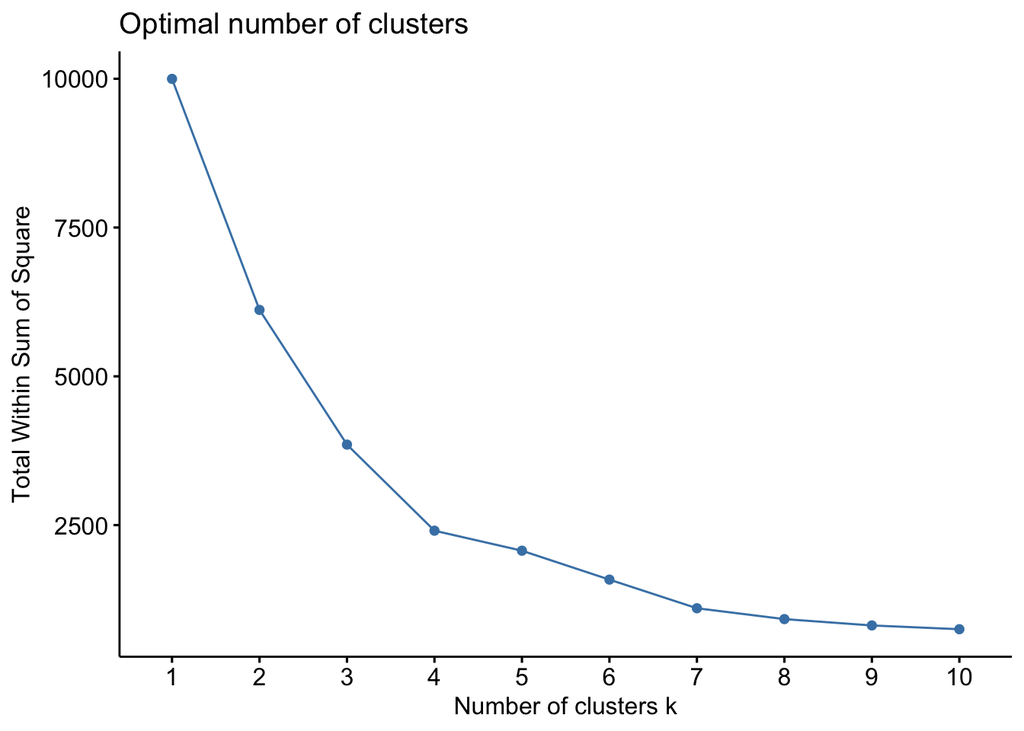

```r
scaled.s1.df <- scale(s1.df)
fviz_nbclust(scaled.s1.df, kmeans, method="wss")
```

#### 2.2.b.ii

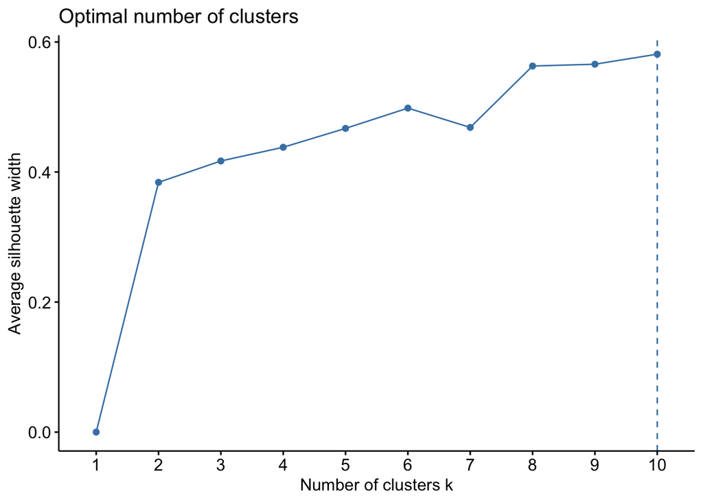

```r
fviz_nbclust(scaled.s1.df, kmeans, method="silhouette")
```

#### 2.2.d.i

```r
k_means <- kmeans(scaled.s1.df, centers=9, nstart=55)
#k_means
```

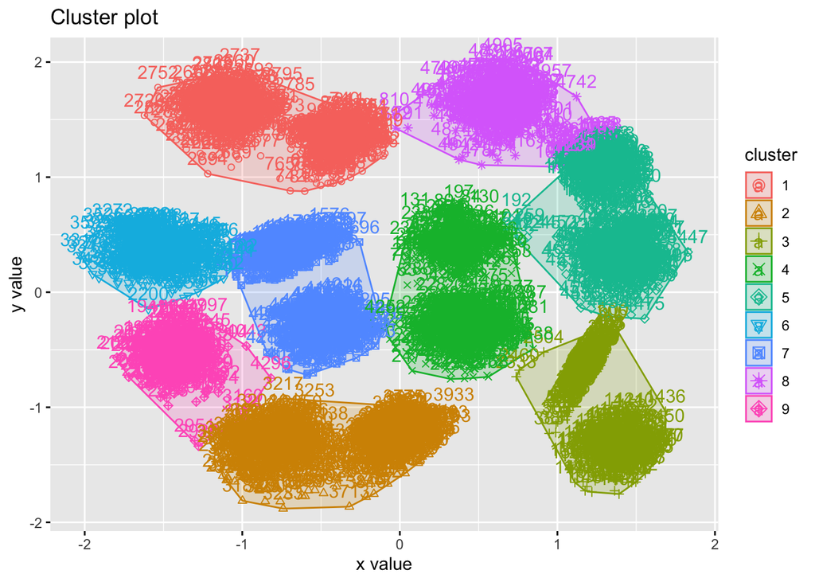

```r
fviz_cluster(k_means, data=scaled.s1.df)
```

#### 2.2.e.i

Even though the data set has 2 features, MinPts as 6 will be an ideal parameter for to spread of points on the edges of some clusters.

#### 2.2.e.ii